# Test the Linear Gaussian Model: A comparison with Kalman-filtering algorithm

Testing pypomp 0.0.6 on 2025-05-15 at run level 2 (0 is for debugging, 2 is full-length).

# Model Setup

We consider a linear Gaussian dynamic system,
$$\begin{align}
X_n &= A X_{n-1} + W_n
\end{align}$$
where $X_n$ is the current state vector, $A$ is the state transition matrix, and $W_n \sim \mathcal{N}(0, Q)$ is the process noise, normally distributed with mean $0$ and covariance $Q$. The measurement model is
$$\begin{align}
Y_n &= C X_n + V_n,
\end{align}$$
where $Y_n$ is the observation vector at time $n$, $C$ is the observation matrix, and $V_n \sim \mathcal{N}(0, R)$ is the observation noise, normally distributed with mean $0$ and covariance $R$.

Here, we build the linear Gaussian POMP model explicitly rather than using `pypomp.LG`. That is in part because the full functionality is not yet in place. For example, we cannot simulate data from a POMP until the class has an `rmeasure`, which is not needed for filtering so has not been fully incorporated.

Set N (length of time series) to be 100 and generate linear Gaussian states and observations:

```python
# po = pypomp.LG(T=10)

def get_thetas(theta):
    A = theta[0:4].reshape(2, 2)
    C = theta[4:8].reshape(2, 2)
    Q = theta[8:12].reshape(2, 2)
    R = theta[12:16].reshape(2, 2)
    return A, C, Q, R

def transform_thetas(A, C, Q, R):
    return jnp.concatenate([A.flatten(), C.flatten(), Q.flatten(), R.flatten()])


fixed = False
key = jax.random.PRNGKey(111)
angle = 0.2
angle2 = angle if fixed else -0.5
A = jnp.array([[jnp.cos(angle2), -jnp.sin(angle)],
             [jnp.sin(angle), jnp.cos(angle2)]])
C = jnp.eye(2)
Q = jnp.array([[1, 1e-4],
             [1e-4, 1]]) # 100
R = jnp.array([[1, .1],
            [.1, 1]]) #/ 10

theta = transform_thetas(A, C, Q, R)

def generate_data(N, key):
    xs = []
    ys = []
    x = jnp.zeros(2)
    for i in range(N):
        key, subkey = jax.random.split(key)
        x = jax.random.multivariate_normal(key=subkey, mean=A @ x, cov=Q)
        key, subkey = jax.random.split(key)
        y = jax.random.multivariate_normal(key=subkey, mean=C @ x, cov=R)
        xs.append(x)
        ys.append(y)
    xs = jnp.array(xs)
    ys = jnp.array(ys)
    return xs, ys, key


def custom_rinit(theta, J, covars=None):
    return jnp.zeros((J, 2))


def custom_rproc(state, theta, key, covars=None):
    A, C, Q, R = get_thetas(theta)
    key, subkey = jax.random.split(key)
    return jax.random.multivariate_normal(key=subkey,
                                          mean=A @ state, cov=Q)


def custom_dmeas(y, preds, theta):
    A, C, Q, R = get_thetas(theta)
    return jax.scipy.stats.multivariate_normal.logpdf(y, preds, R)


rinit = custom_rinit
rproc = custom_rproc
dmeas = custom_dmeas
rprocess = jax.vmap(custom_rproc, (0, None, 0, None))
dmeasure = jax.vmap(custom_dmeas, (None, 0, None))
rprocesses = jax.vmap(custom_rproc, (0, 0, 0, None))
dmeasures = jax.vmap(custom_dmeas, (None, 0, 0))
```

Set J=10000 particles and compare the estimated log-likelihood between Kalman filtering and the log-mean-exponential computed over 100 replications for various methods, including classical particle filtering and MOP, etc.

```python
xs, ys, key = generate_data(N, key)
kf = pykalman.KalmanFilter(
    transition_matrices=A, observation_matrices=C,
    transition_covariance=Q, observation_covariance=R,
    initial_state_covariance=Q)
print("kf loglik =", kf.loglikelihood(ys))
```

```
kf loglik = -378.402440173952
```

```python
pickle_file = out_dir + "/pfilter-test.pkl"
if (os.path.exists(pickle_file)):
    loglike = pickle.load(open(pickle_file,'rb'))
else:
    loglike = []
    for i in range(N_reps):
        key, subkey = jax.random.split(key)
        pfilter_val = -_pfilter_internal(
            theta, ys, J = J, rinit = rinit,
            rprocess = rprocess, dmeasure = dmeasure,
            covars = None, key= subkey, thresh = -1)
        loglike.append(pfilter_val)
    pickle.dump(loglike,open(pickle_file,'wb'))

loglike_ = jnp.array(loglike)

print("Logmeanexp of Particle Filtering =", logmeanexp(loglike))
print("SE on logmeanexp  =", logmeanexp_se(loglike_))
print("difference between Kalman-Filtering and logmeanexp of Particle Filtering =",
    kf.loglikelihood(ys) - (logmeanexp(loglike)))
```

```
Logmeanexp of Particle Filtering = -378.45117
SE on logmeanexp  = 0.03881513
difference between Kalman-Filtering and logmeanexp of Particle Filtering = 0.048736572
```

We check that the difference between the Kalman filter log-likelihood and the particle filter log-likelihood is comparable to the Monte Carlo error, and that the Monte Carlo error is small as a result of many particles and many replications.

Next, we test the ouput of the MOP algorithm. The pypomp MOP algorithm is set to be $\phi = \theta$. Under this case, the MOP algorithm should be equivalent with the particle filter algorithm, and have the same output values when setting the same random seeds.

```python
alphas = [0, 0.1, 0.3, 0.6, 0.9, 1]



key = jax.random.PRNGKey(0)  # Use a fixed seed for reproducibility
subkeys = jax.random.split(key, 100)  # Pre-generate 100 keys

pickle_file = out_dir + "/test-alpha.pkl"
if (os.path.exists(pickle_file)):
    file=open(pickle_file,'rb')
    results = pickle.load(file)
    loglike_pf = pickle.load(file)
else:
    results = []
    for alpha in alphas:
        loglike_mop = []
        for i, subkey in enumerate(subkeys):
            mop_val = -_mop_internal(theta, ys, J=J, rinit=rinit,
                rprocess=rprocess, dmeasure=dmeasure,
                covars=None, key=subkey, alpha=alpha)
            loglike_mop.append(mop_val)
        loglike_mop = jnp.array(loglike_mop)
        logmeanexp_val = logmeanexp(loglike_mop)
        difference = kf.loglikelihood(ys) - logmeanexp_val
        results.append((alpha, logmeanexp_val, difference))
    # Use the same random key to test the particle filter output
    loglike_pf = []
    for i, subkey in enumerate(subkeys):
        pfilter_val = -_pfilter_internal(
            theta, ys, J = J, rinit = rinit,
            rprocess = rprocess, dmeasure = dmeasure,
            covars = None, key= subkey, thresh = -1)
        loglike_pf.append(pfilter_val)
    file = open(pickle_file,'wb')
    pickle.dump(results,file)
    pickle.dump(loglike_pf,file)


alpha_table=tabulate(results, tablefmt="grid", headers=("alpha","pf","kalman-pf"))
print(alpha_table)
```

alpha

```
  pf
```

kalman-pf

```
0
```

-378.452

0.0491028

```
0.1
```

-378.452

0.0491028

```
0.3
```

-378.452

0.0491028

```
0.6
```

-378.452

0.0491028

```
0.9
```

-378.452

0.0491333

```
1
```

-378.452

0.0491028

### Test the Linear Gaussian Model: How estimate logllikehood difference and running time varys among different N and J

```python
pickle_file = out_dir + "/N-J-test.pkl"
if (os.path.exists(pickle_file)):
    NJresults = pickle.load(open(pickle_file,'rb'))
else:
    NJresults = []
    key = jax.random.PRNGKey(112)
    for N_val in N_values:
        for J_val in J_values:
            print(f"Running with N={N_val}, J={J_val}...")

            xs, ys, key = generate_data(N_val, key)
            pf_loglik_arr = []
            mop_loglik_arr = []
            elapsed_time1_arr = []
            elapsed_time2_arr = []

            for i in range(N_reps):
                start_time = time.time()
                pf_val = -pfilter(J = J_val,
                rinit = rinit, rprocess = rprocess, dmeasure = dmeasure,
            theta = theta, ys = ys, thresh = 0, key = key)
                pf_loglik_arr.append(pf_val)
                elapsed_time1_arr.append(time.time() - start_time)

                start_time2 = time.time()
                mop_val = -mop(J = J_val,
                rinit = rinit, rprocess = rprocess, dmeasure = dmeasure,
            theta = theta, ys = ys, alpha = 0.9, key = key)
                mop_loglik_arr.append(mop_val)
                elapsed_time2_arr.append(time.time() - start_time2)

            pf_loglik_arr = jnp.array(pf_loglik_arr)
            mop_loglik_arr = jnp.array(mop_loglik_arr)
            elapsed_time1_arr = jnp.array(elapsed_time1_arr)
            elapsed_time2_arr = jnp.array(elapsed_time2_arr)

            NJresults.append({
                'N': N_val,
                'J': J_val,
                'pf_loglik': logmeanexp(pf_loglik_arr),
                'time_pfilter': jnp.mean(elapsed_time1_arr),
                'mop_loglik': logmeanexp(mop_loglik_arr),
                'time_mop': jnp.mean(elapsed_time2_arr),
            })
    pickle.dump(NJresults,open(pickle_file,'wb'))
```

```python
table=tabulate(NJresults, tablefmt="grid", headers="keys")
print(table)
```

N

```
J
```

pf_loglik

time_pfilter

mop_loglik

time_mop

100

10

-426.772

```
0.00331634
```

```
-426.772
```

0.00347745

100

100

-400.311

```
0.00592121
```

```
-400.311
```

0.00622481

100

1000

-354.355

```
0.0264283
```

```
-354.399
```

0.0313027

100

10000

-364.488

```
0.152326
```

```
-364.479
```

0.164319

500

10

-2068.8

```
0.00650719
```

-2068.8

0.00674063

500

100

-1916.43

```
0.0150236
```

-1916.43

0.0178326

500

1000

-1875.09

```
0.106222
```

-1875.69

0.111074

500

10000

-1856.49

```
0.616038
```

-1858.5

0.641503

### Log Likelihood vs. Particle Number for Particle Filter and MOP

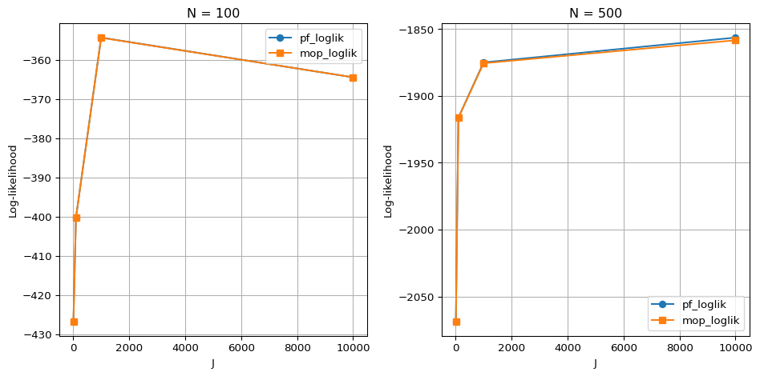

```python
df = pd.DataFrame(NJresults)
unique_N = df['N'].unique()
num_panels = len(unique_N)

# Set up the subplots
fig, axes = plt.subplots(nrows=1, ncols=num_panels, figsize=(5 * num_panels, 5), sharey=False)

if num_panels == 1:
    axes = [axes]  # Ensure axes is iterable if there's only one panel

for ax, N_val in zip(axes, unique_N):
    sub_df = df[df['N'] == N_val]
    sub_df = sub_df.sort_values('J')  # Ensure lines connect in correct order

    ax.plot(sub_df['J'], sub_df['pf_loglik'], label='pf_loglik', marker='o')
    ax.plot(sub_df['J'], sub_df['mop_loglik'], label='mop_loglik', marker='s')

    ax.set_title(f'N = {N_val}')
    ax.set_xlabel('J')
    ax.set_ylabel('Log-likelihood')
    ax.legend()
    ax.grid(True)

plt.tight_layout()
plt.show()
```

### Runtime vs. Particle Number J for Particle Filter and MOP

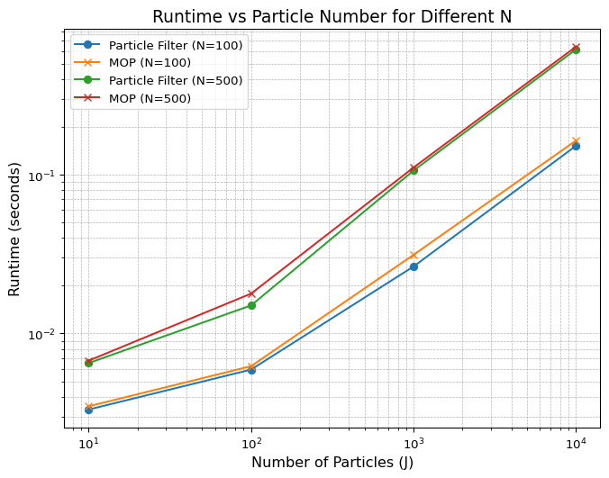

```python
plt.figure(figsize=(8, 6))
for N_val in unique_N:
    sub_df = df[df['N'] == N_val]
    plt.plot(sub_df['J'], sub_df['time_pfilter'], label=f'Particle Filter (N={N_val})', marker='o')
    plt.plot(sub_df['J'], sub_df['time_mop'], label=f'MOP (N={N_val})', marker='x')

plt.xscale('log')
plt.yscale('log')
plt.xlabel('Number of Particles (J)', fontsize=12)
plt.ylabel('Runtime (seconds)', fontsize=12)
plt.title('Runtime vs Particle Number for Different N', fontsize=14)
plt.legend(fontsize=10)
plt.grid(True, which="both", linestyle="--", linewidth=0.5)
plt.show()
```

memory requirement scales (J,N) for autodiff? - How much RAM we use

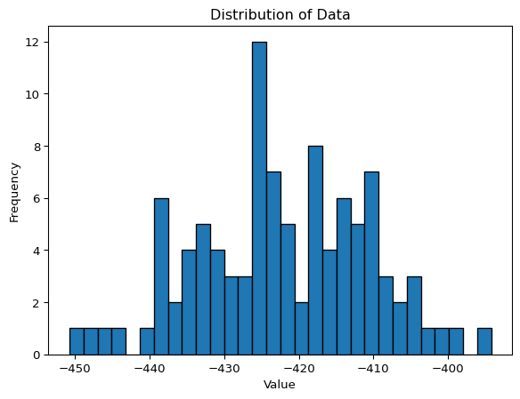

```python
J = 10
nrep = N_reps
pypf_loglik_arr = []
xs, ys, key = generate_data(N, key)
for i in range(nrep):
    key, subkey = jax.random.split(key)
    pf_val = -pfilter(J = J,
        rinit = rinit, rprocess = rprocess, dmeasure = dmeasure,
    theta = theta, ys = ys, thresh = 2, key=subkey)
    pypf_loglik_arr.append(pf_val)

plt.hist(pypf_loglik_arr, bins=30, edgecolor='black')
plt.title("Distribution of Data")
plt.xlabel("Value")
plt.ylabel("Frequency")
# plt.show()
```